# RB3 Benchmarks

## Small Size GEMM

```
taskset -c 4 perf stat -e cycles,instructions ./gemm_sdot_benchmark
```

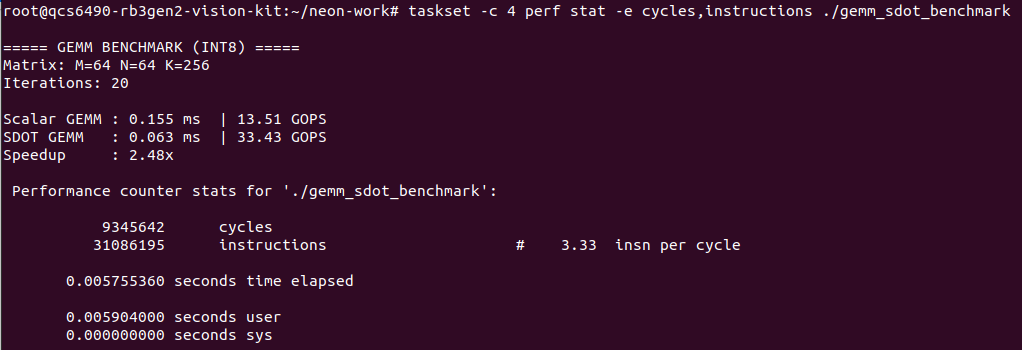

### Observing Accumulator effect

```
taskset -c 4 perf stat -e cycles,instructions,stall_frontend,stall_backend,stall_backend_mem,stall_slot,stall_slot_backend,stall_slot_frontend ./gemm_sdot_benchmark
```

[figure not shown]

# Understanding CPU Stall Counters (ARM perf stat)

These counters help explain *why* a program is fast or slow at the microarchitecture level.

## CPU Hardware Scheduler

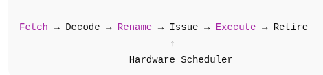

## 1. `stall_frontend`

**What it means:**

- Cycles where the CPU frontend cannot deliver instructions
- Causes:
  - Instruction cache misses
  - Branch mispredictions
  - Decode bottlenecks

**Interpretation:**

- Low value ⇒ frontend is healthy
- High value ⇒ code layout or branching problems

## 2. `stall_backend`

**What it means:**

- Cycles where the backend cannot make progress
- Causes:
  - Execution unit contention
  - Data dependencies
  - Instruction latency (e.g., SDOT)

**Interpretation:**

- High value ⇒ compute pipeline limitations
- Reduced by:
  - Multiple accumulators
  - Instruction-level parallelism (ILP)

## 3. `stall_backend_mem`

**What it means:**

- Backend stalls caused specifically by memory
- Includes:
  - L1/L2 cache misses
  - DRAM access delays

**Interpretation:**

- Low value ⇒ compute-bound
- High value ⇒ memory-bound
- Fixed using:
  - Cache blocking
  - Data reuse
  - Prefetching

## 4. `stall_slot`

**What it means:**

- Number of CPU issue slots that were not used
- Indicates lost instruction issue opportunities

**Interpretation:**

- High value is normal in tight loops
- Must be analyzed with sub-counters

## 5. `stall_slot_backend`

**What it means:**

- Unused issue slots due to backend limitations

**Interpretation:**

- High value ⇒ execution unit saturation
- Common in optimized compute kernels

## 6. `stall_slot_frontend`

**What it means:**

- Unused issue slots due to frontend starvation

**Interpretation:**

- Low value ⇒ frontend is not a bottleneck
- High value ⇒ fetch/decode inefficiency

## Key Takeaway

> Accumulators reduce backend stalls by hiding latency.  
> Once latency is hidden, execution width and memory bandwidth become the limits.

### Dependency Graph for Two accumulatros

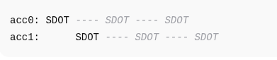

## Big Size GEMM with Small Size GEMM

```
format: ./gemm_sdot_benchmark_cli  M  N  K  ACC

taskset -c 7 ./gemm_sdot_bench_cli 512 512 1024 2
taskset -c 7 ./gemm_sdot_bench_cli 64 64 256 2
```

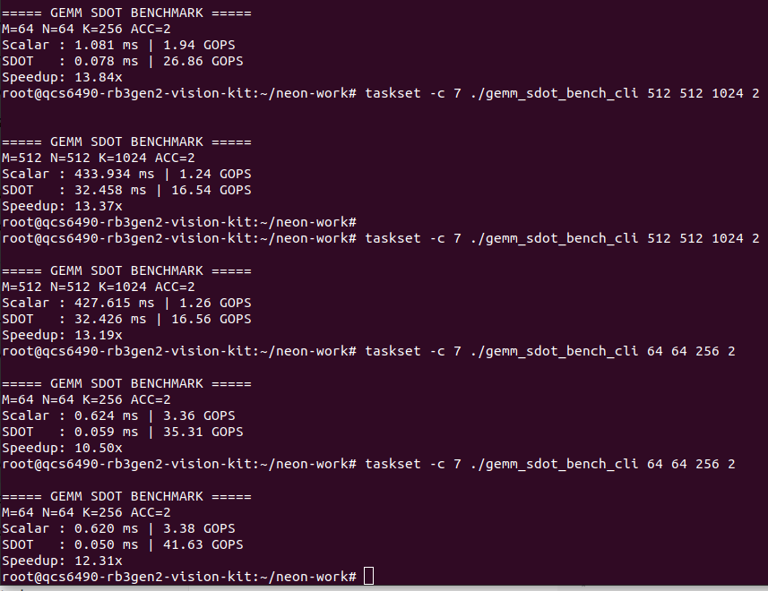